# Figuring Out Liver

The purpose of this document is to examine why liver appears to have more tissue specificity in terms of lfsr but not in terms of sharing of effects. First, let’s reload those plots and make sure things are computed correctly:

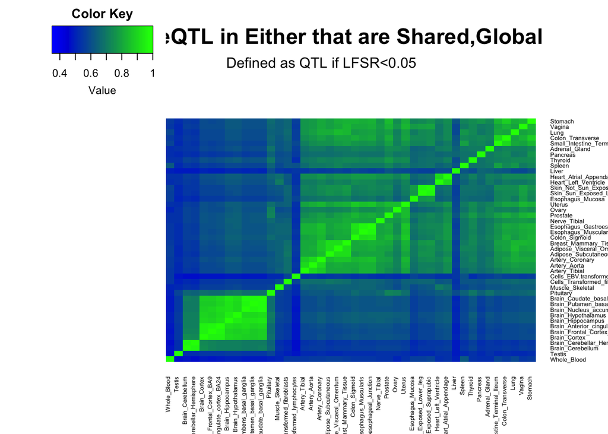

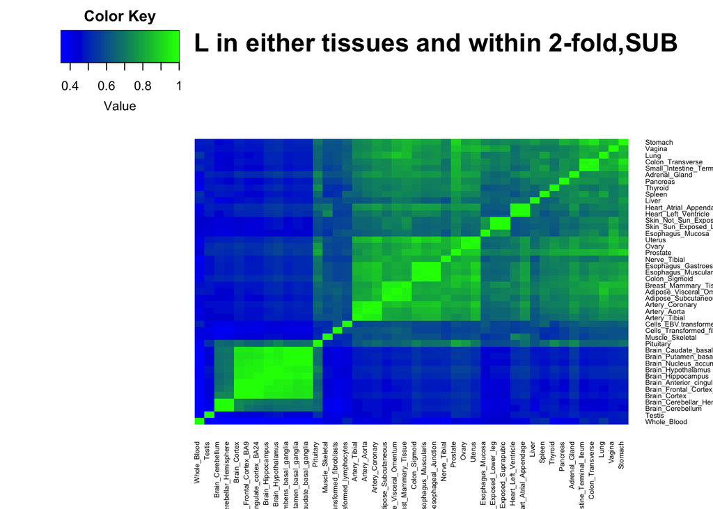

But note that if we use the orders induced by signficiance, the ‘clarity’ of the effect size plot becomes more evident.

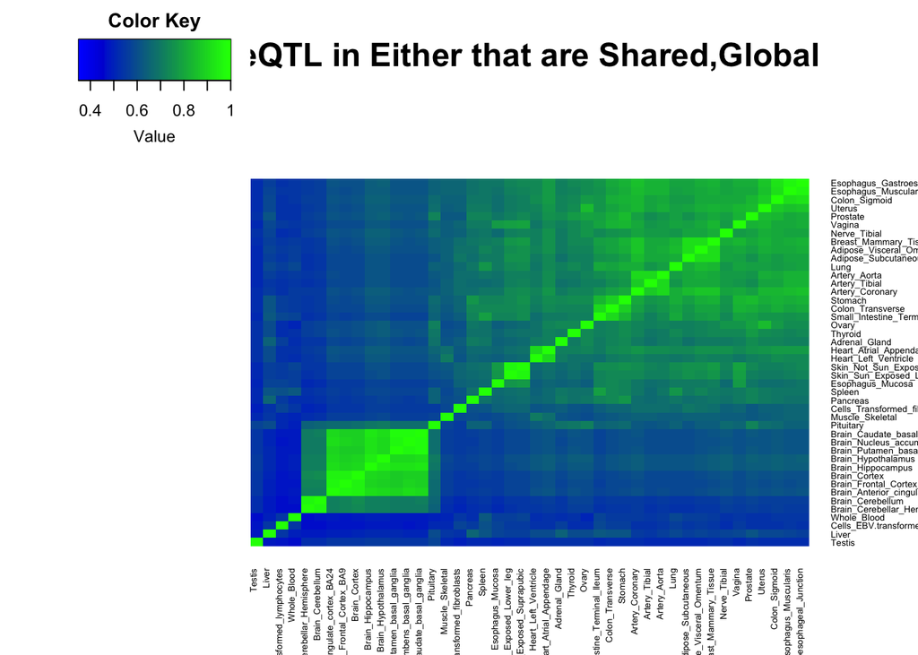

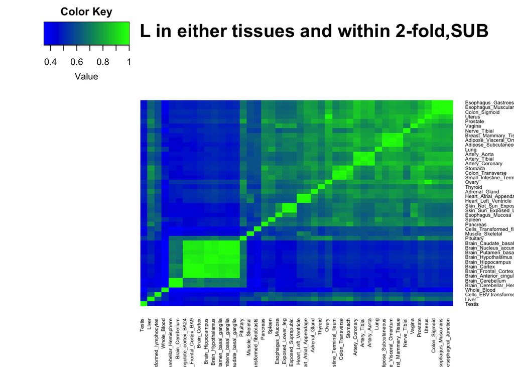

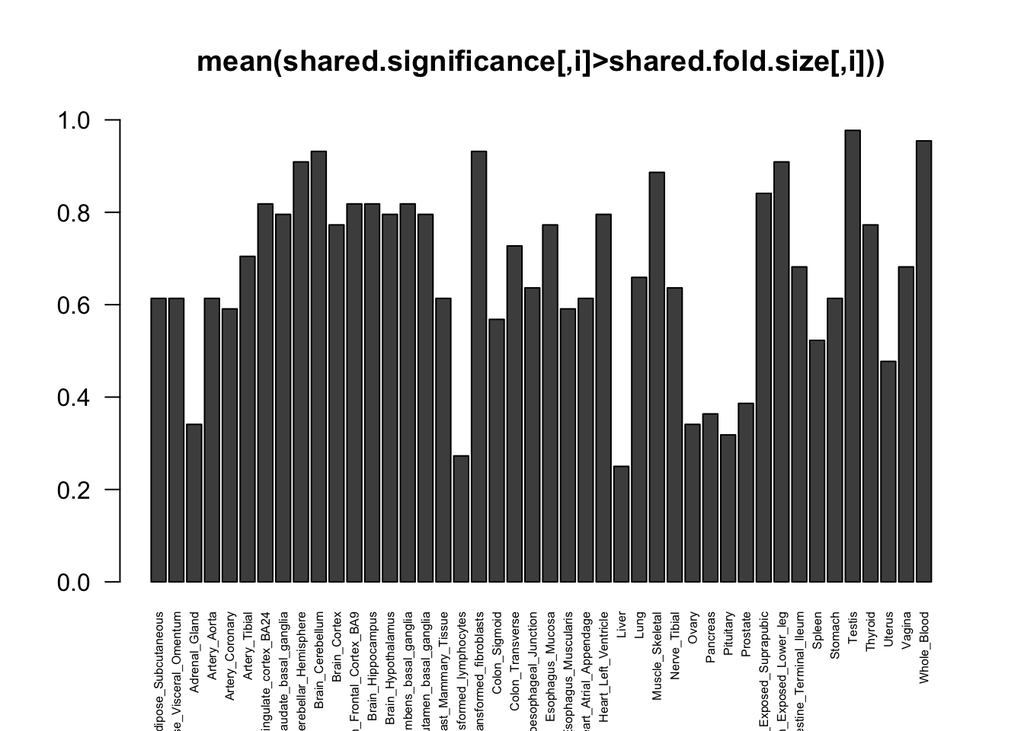

This seems unusual, so let’s look at the lfsrs and posterior effects from which this data is computed. For each tissue, we compute the mean absolute value of the effect across genes and we do a gut check with the initial input univariate beta hats to make sure they look ‘similar’.

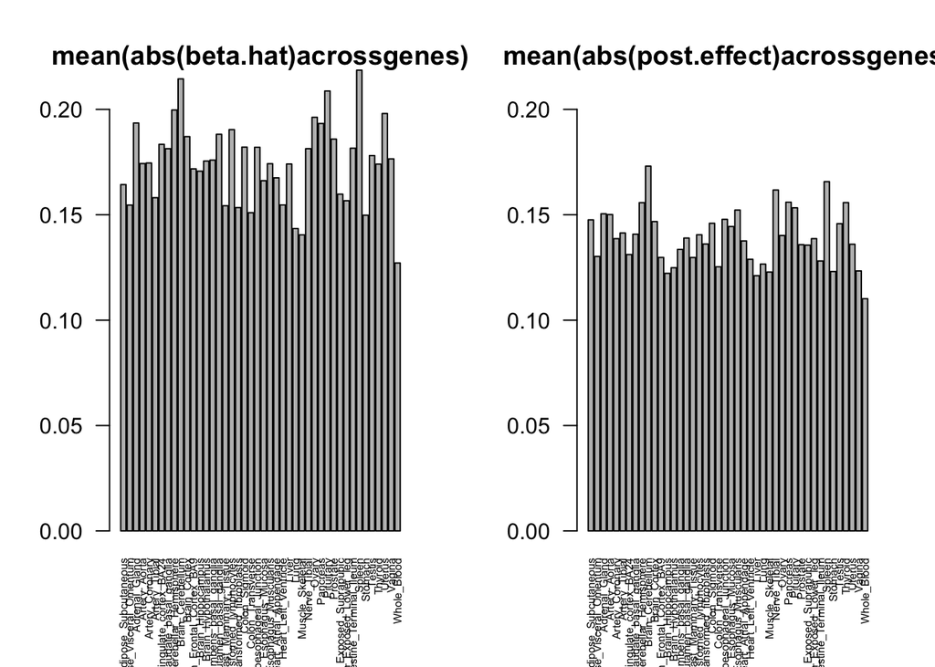

So now, let’s consider the lfsr:

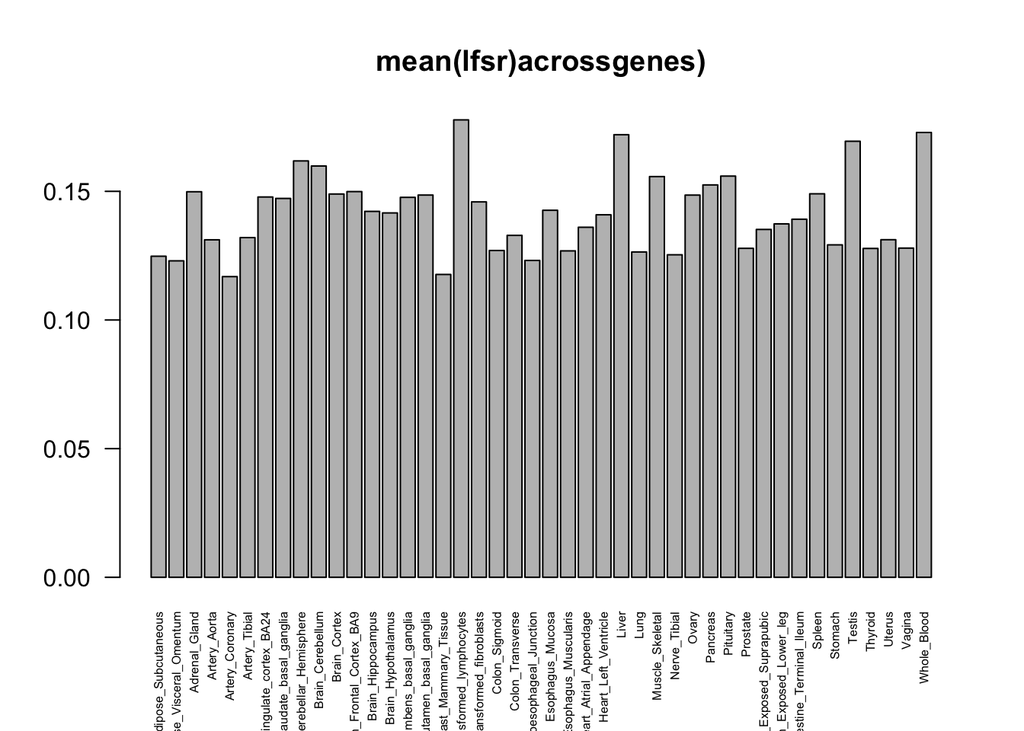

We can see that while liver effect sizes are’t ‘unusually low’ they are shrunk, more than other tissues of their same size. Also, their average lfsr seems to be higher. I think this is because the standard error of liver is on the high side.

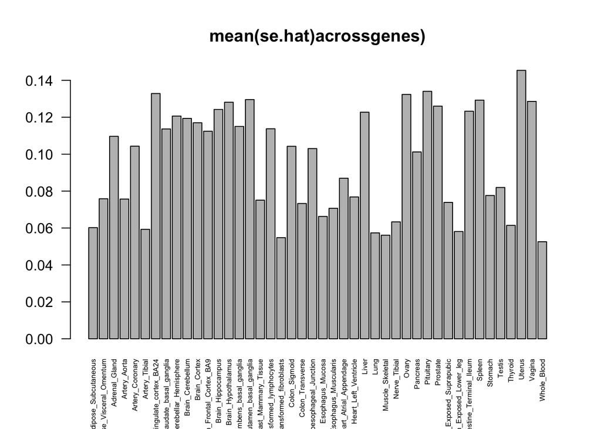

The posterior means are towards the bottom as the rank among tissues ( 43 ) as computed as the average absolute beta.hat across genes for every tissue.

And accordingly, it has one of the higher mean lfsrs across tissues (ranks 3) as computed as the mean lfsr across genes for every tissue .

```r
i=27
j=1

sig.tissuei=which(lfsr.mash[,i]<thresh)
sig.tissuej=which(lfsr.mash[,j]<thresh)
a=(union(sig.tissuei,sig.tissuej))



lfsr.tissuei=lfsr.mash[a,i]
lfsr.tissuej=lfsr.mash[a,j]
quotient=(pm.mash.beta[a,i]/pm.mash.beta[a,j])
weirdos=a[which(quotient>0.5&quotient<2&lfsr.tissuei>0.05&lfsr.tissuej<0.05)]

head(data.frame(lfsr.liver=lfsr.mash[weirdos,i],lfsr.j=lfsr.mash[weirdos,j],mash.beta.liver=pm.mash.beta[weirdos,i],mash.beta.j=pm.mash.beta[weirdos,j],standard.error.liver=standard.error[weirdos,i],standard.error.j=standard.error[weirdos,j]))
```

```
##   lfsr.liver       lfsr.j mash.beta.liver mash.beta.j standard.error.liver
## 1 0.09636994 5.703681e-04      0.07040373  0.05610037           0.20564021
## 2 0.15052657 5.262140e-05      0.07530060  0.14026860           0.10601098
## 3 0.11676381 5.924657e-03     -0.04141672 -0.05881809           0.08827984
## 4 0.07130140 2.512465e-09     -0.18371499 -0.28199507           0.14784768
## 5 0.25072811 3.436534e-02      0.07009383  0.06041015           0.12732409
## 6 0.07971779 9.190182e-03     -0.04603124 -0.03834859           0.10983973
##   standard.error.j
## 1       0.04623766
## 2       0.05336426
## 3       0.04923381
## 4       0.06250005
## 5       0.04220142
## 6       0.03920107
```

```r
i=27
j=20

sig.tissuei=which(lfsr.mash[,i]<thresh)
sig.tissuej=which(lfsr.mash[,j]<thresh)
a=(union(sig.tissuei,sig.tissuej))

lfsr.tissuei=lfsr.mash[a,i]
lfsr.tissuej=lfsr.mash[a,j]
quotient=(pm.mash.beta[a,i]/pm.mash.beta[a,j])
weirdos=a[which(quotient>0.5&quotient<2&lfsr.tissuei>0.05&lfsr.tissuej<0.05)]

head(data.frame(lfsr.liver=lfsr.mash[weirdos,i],lfsr.j=lfsr.mash[weirdos,j],mash.beta.liver=pm.mash.beta[weirdos,i],mash.beta.j=pm.mash.beta[weirdos,j],standard.error.liver=standard.error[weirdos,i],standard.error.j=standard.error[weirdos,j]))
```

```
##   lfsr.liver       lfsr.j mash.beta.liver mash.beta.j standard.error.liver
## 1 0.09636994 3.424700e-04      0.07040373  0.08519123           0.20564021
## 2 0.15052657 8.783295e-03      0.07530060  0.11632715           0.10601098
## 3 0.25072811 2.306950e-02      0.07009383  0.09640559           0.12732409
## 4 0.07971779 2.794248e-02     -0.04603124 -0.06314419           0.10983973
## 5 0.05343446 2.663637e-08      0.06905875  0.10660882           0.06960905
## 6 0.18288928 1.386161e-02      0.02962692  0.05521014           0.11042012
##   standard.error.j
## 1       0.10867102
## 2       0.10817449
## 3       0.08369784
## 4       0.11882838
## 5       0.04678368
## 6       0.09344807
```

Though the standard error is high, it doesn’t stand out relative to uterus, vagina, ovary and the brains, but recall that those are tissues in which our prior captures frequent sharing, meaning that they will tend to share both effects and significance, and significant effects in one of their shared tissues will tend to induce significance and larger effects in both.